# Problem Background:

An experiment to test content was run on one of our games. The experiment had three variants each with a different content set. The aim of the experiment was to determine the variant with the optimum balance of economy, engagement and retention.

# Retention

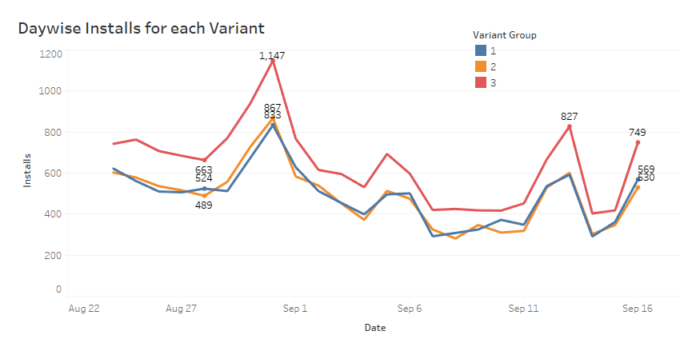

No of installs are almost similar for variant 1 and 2, whereas installs for variant 3 are higher over the given time period

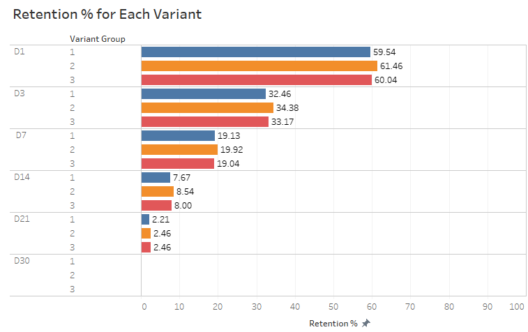

# Engagement

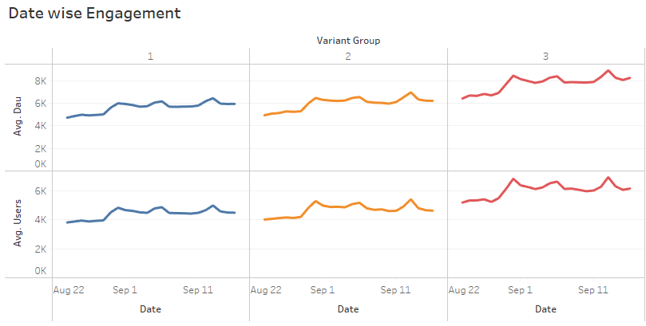

Avg DAU and Avg User Engagement is similar for Variants 1 and 2, whereas these are higher for Variant 3 over the given period of time

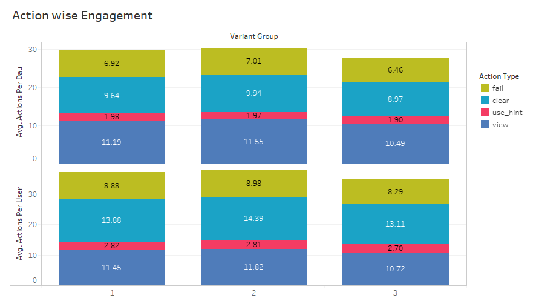

Avg Actions per DAU and Avg Actions per User are highest for variant 2 for the 3 actions - view,clear and fail, for use_hint variant 2 is almost similar to Variant 1.

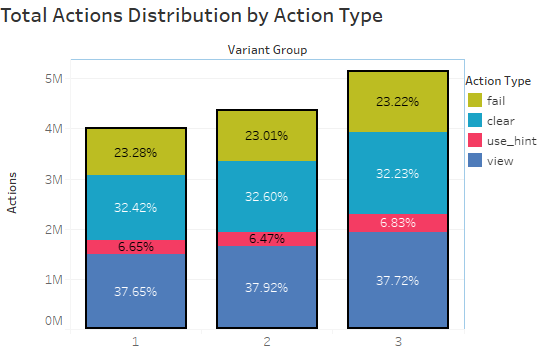

It is seen that view is the predominant action performed comprising of around 38% of total actions, followed by clear, fail and use_hint actions. This trend is constant across variants.

# Economy

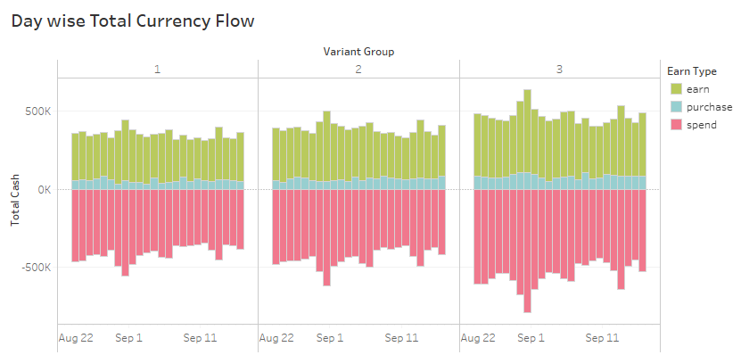

The currency flow of total coins - earn,spend and purchase is highest in Variant 3 ,could be due to higher installs and higher DAU over the given period of time

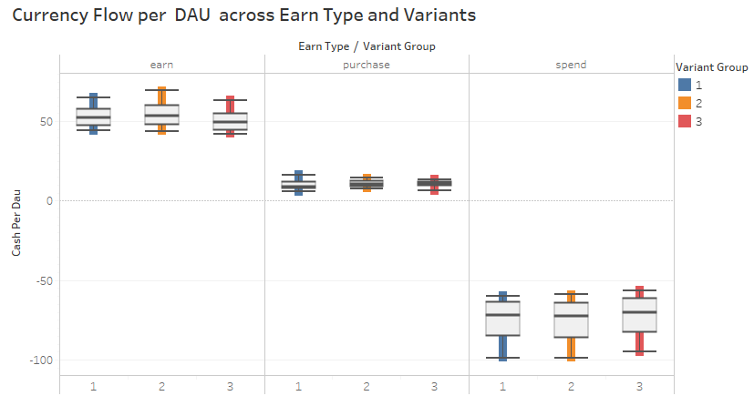

The boxplots show the currency flow per DAU for earn,spend and purchase across the variants.Variant 2 has highest earn,purchase and spend per DAU among the variants. This shows higher positive flow and higher negative flow of coins as compared to other variants,leading to the most balanced variant among the variants

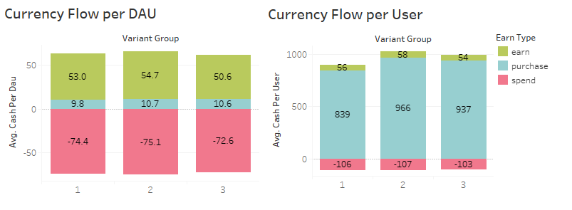

It is seen that Currency Flow per DAU and Currency Flow per User for earn,purchase and spend is maximum for Variant 2 among all variants.Considering the Currency Flow per DAU above, earn + purchase =Source absolute spend =Sink For game to have a balanced economy, Source/Sink ratio should be close to 1. Ratio for variant 1 = 0.84 Ratio for Variant 2 = 0.87 Ratio for Variant 3 = 0.84

Variant 2 with the highest Source to Sink Ratio has the most balanced economy among all variants.

# Which Variant is our Winner?

1. Retention - Variant 2 has the maximum retention rate, although the no of installs in Variant 3 are more throughout the time period , but the retention rate in Variant 3 is slightly less than Variant 2.
2. Engagement - Variant 2 has the maximum actions per DAU and per User (clear,fail,view,use_hint), followed by Variant 1 (almost similar in terms of use_hint),although the Avg DAU and Users are higher in Variant 3 throughout the given period of time. This means that the users were quick to engage in Variant 3, due to higher installs but the actions per user is lower than Variant 2.
3. Economy - Variant 2 has the maximum earn,purchase and spend per DAU and per User, also the source to sink ratio is closet to 1 among other variants.It is closely followed by Variant 3. The total currency flow can be misleading as the users and DAU are more in case of Variant 3.

# Based on consistent good performance on the above 3 metrics , Variant 2 is our winner.

# Rank the variants in the order of their difficulty

Difficulty of the Game Variant can be decided based on :

1. Engagement Activities - The proportion of use_hint ,clear and fail actions out of all the actions in that variant.Higher proportion of use_hint and fail actions and lower proportion of clear action indicate higher difficulty in the variant.
2. Economy - Source and Sink flow, Higher source by earn indicates easy earning and progression, while Higher Sink indicates difficulty in progression without spending. Also, Lower Source to Sink ratio indicates higher difficulty as more sink is required to progress in the game.

Based on above two factors, we will order the difficulty on the variant groups.

use_hint proportion - Variant 3 > Variant 1 > Variant 2 clear proportion - Variant 2 > Variant 1 > Variant 3 fail proportion - Variant 1 > Variant 3 > Variant 2

From the above actions, Difficulty - Variant 3 > Variant 1 > Variant 2

Source to Sink Ratios per DAU for variants - Variant 1 - 0.844 Variant 2 - 0.87 Variant 3 - 0.847 Variant 2 has highest Ratio, so it is the least difficult , Variant 1 and Variant 3 have similar source to sink ratio.

Difficulty of the Game Variant can be decided based on :

1. Engagement Activities - The average per DAU values of use_hint ,clear and fail actions in that variant can tell about the difficulty level. Higher average per DAU value of use_hint and fail actions and lower average per DAU value of clear action indicate higher difficulty in the variant.
2. Economy - The spend of coins on hints can tell us about the difficulty level of the variant. Higher Sink indicates difficulty in progression without spending coins to use hints.

Based on above two factors :

avg use_hint actions per DAU - Variant 1 ~ Variant 2 > Variant 3 avg clear actions per DAU - Variant 2 > Variant 1 > Variant 3 avg fail actions per DAU - Variant 2 > Variant 1 > Variant 3

From the above actions, Difficulty - Variant 2 > Variant 1 > Variant 3

avg spend to get hints per DAU - Variant 2 > Variant 1 > Variant 3

From the above spend metric, Difficulty - Variant 2 > Variant 1 > Variant 3

# Hence, order of Difficulty is Variant 2 > Variant 1 > Variant 3